# Description

## Visualize predictions for x_test[2], x_test[3], x_test[33], x_test[36], x_test[59]. (5 Marks)

```
x_test[2] Predicted: Cleavers
x_test[2] Actual: Cleavers
```

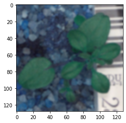

```python
# Cell# 25
x_test_2_pred_res=classifier.predict(X_test[2].reshape(1,128,128,3))
x_test_2_pred_res_class = np.argmax(x_test_2_pred_res)
print(f'x_test[2] Predicted: {plants[x_test_2_pred_res_class]}')
print(f'x_test[2] Actual: {plants[y_test_e[2]]}')
plt.imshow(X_test[2])
```

```
x_test[3] Predicted: Fat Hen
x_test[3] Actual: Fat Hen
```

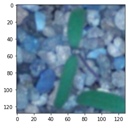

```python
# Cell# 26
x_test_3_pred_res=classifier.predict(X_test[3].reshape(1,128,128,3))
x_test_3_pred_res_class = np.argmax(x_test_3_pred_res)
print(f'x_test[3] Predicted: {plants[x_test_3_pred_res_class]}')
print(f'x_test[3] Actual: {plants[y_test_e[3]]}')
plt.imshow(X_test[3])
```

```
x_test[33] Predicted: Scentless Mayweed
x_test[33] Actual: Scentless Mayweed
```

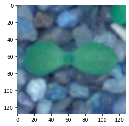

```python
# Cell# 27
x_test_33_pred_res=classifier.predict(X_test[33].reshape(1,128,128,3))
x_test_33_pred_res_class = np.argmax(x_test_33_pred_res)
print(f'x_test[33] Predicted: {plants[x_test_33_pred_res_class]}')
print(f'x_test[33] Actual: {plants[y_test_e[33]]}')
plt.imshow(X_test[33])
```

```
x_test[36] Predicted: Scentless Mayweed
x_test[36] Actual: Common Chickweed
```

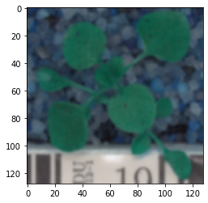

```python
# Cell# 28
x_test_36_pred_res=classifier.predict(X_test[36].reshape(1,128,128,3))
x_test_36_pred_res_class = np.argmax(x_test_36_pred_res)
print(f'x_test[36] Predicted: {plants[x_test_36_pred_res_class]}')
print(f'x_test[36] Actual: {plants[y_test_e[36]]}')
plt.imshow(X_test[36])
```

```
x_test[59] Predicted: Loose Silky-bent
x_test[59] Actual: Loose Silky-bent
```

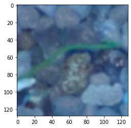

```python
# Cell# 29
x_test_59_pred_res=classifier.predict(X_test[59].reshape(1,128,128,3))
x_test_59_pred_res_class = np.argmax(x_test_59_pred_res)
print(f'x_test[59] Predicted: {plants[x_test_59_pred_res_class]}')
print(f'x_test[59] Actual: {plants[y_test_e[59]]}')
plt.imshow(X_test[59])
```

# Map of project outcomes

| Section | Code Cells |
| --- | --- |
| Import the libraries, load dataset, print shape of data, visualize the images in dataset. (5 Marks) | Cell# **1-6** |
| Data Pre-processing: (15 Marks) | Cell# **7-9** |
| Make data compatible: (10 Marks) | Cell# **10-13** |
| Building CNN: (15 Marks) | Cell# **14-16** |
| Fit and evaluate modeland print confusion matrix. (10 Marks) | Cell# **17-24** |
| Visualize predictions for x_test[2], x_test[3], x_test[33], x_test[36], x_test[59]. (5 Marks) | Cell# **25-29** |

# What additional optimizations could have been performed.

- I could have augmented the data to try and improve the model performance by creating synthetic examples (especially for the minority classes).
- Tried with grayscale images (convert the images to grayscale in the preprocessing steps) - my hypothesis is that it would have reduced the overfitting a bit between test and validation sets (due to dimensionality reduction).

Due to shortage of time and I did not perform these tasks but I would surely play around with the above measures to see if we get any better results later on.